### Analysis of data from a personal activity monitoring device

The following is the result of analyses carried out on data obtained from a personal activity monitoring device. The analyses were conducted as requested in the Peer Assessment 1 of the Reproducible Research module offered as part of the Data Science Specialization on www.coursera.org.

**Loading and preprocessing the data**

First, we load the data from the activity.csv file which is located on the working directory

```r
data <- read.csv(file = "activity.csv", stringsAsFactors=FALSE, na.strings="NA")
```

Then we process the data to format the date column.

```r
data$date <- strptime(data$date, "%Y-%m-%d")
```

**What is mean total number of steps taken per day?**

[figure not shown]

```r
plot(data$date, data$steps, type = "h", main = "Total number of steps taken each day", ylab = "Number of steps", xlab = "Date")
```

```r
meansteps <- mean(data$steps, na.rm=TRUE)
mediansteps <- median(data$steps, na.rm=TRUE)
##The mean number of steps is `r meansteps` and the median number of steps is `r mediansteps`. Please note that missing values have been ignored.
```

**What is the average daily activity pattern?**

1. Firstly, we need to extract out the average number of steps taken for every 5 minute interval. Then we plot the output.

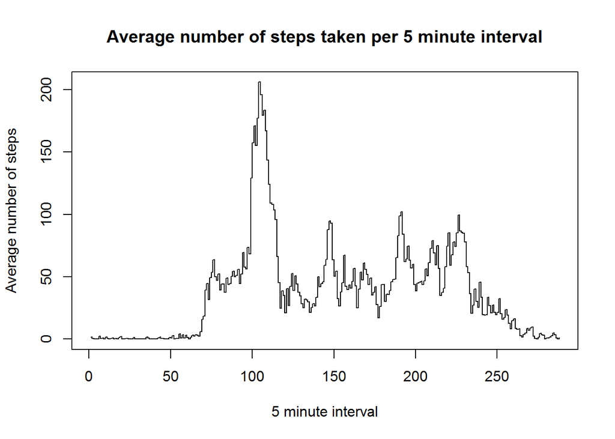

```r
DAP <- sapply(split(data$steps, data$interval), mean, na.rm=TRUE)
plot(DAP, type = "s", main = "Average number of steps taken per 5 minute interval", ylab = "Average number of steps", xlab = "5 minute interval")
```

2. We then calculate the max 5 minute interval and return it in the text below

```r
maxDAP <- which(DAP == max(DAP))
##The 5-minute interval, on average across all the days in the dataset, which contains the maximum number of steps, is the `r maxDAP`th interval.
```

The 5-minute interval, on average across all the days in the dataset, which contains the maximum number of steps, is the 104th interval.

**Imputing missing values**

1. First, we calculate and report the total number of missing values in the dataset

```r
sumNA <- sum(is.na(data$steps))
## The total number of missing values in the dataset is `r sumNA`.
```

The total number of missing values in the dataset is 2304.